# Machine Learning

## Indah Agustien Siradjuddin

## Convolutional Neural Network

Semester Gasal 2019-2020

*Deep Learning* memiliki arsitektur Jaringan Syaraf Tiruan yang memiliki lebih banyak layer dan neuron (*deeper* dan *wider*). Setiap layer memiliki fungsi tersendiri. Kelebihan dari Deep Learning :

- Arsitektur yang lebih banyak layer dan neuron, dapat menangkap data secara detil
- Tidak dibutuhkan *Feature engineering*, deep learning memiliki kemampuan *feature learning*

Convolutional Neural Network - CNN, merupakan salah satu arsitektur Deep learning.

Architecture of CNN :

[figure not shown]

### Convolutional Layers :

- *Image Convolution : $n$ kernels atau filters
- Setiap channel dari citra dikonvolusi dengan setiap kernel
- Jumlahkan semua hasil konvolusi : feature maps. Oleh karena itu, jika terdapat $n$ kernel, maka jumlah *feature map* yang dihasilkan adalah $n$

[figure not shown]

### Rectified Linear Units (RELU)

Fungsi aktivasi RELU activation digunakan agar semua nilai pada *feature maps* adalah positif : \begin{eqnarray} f(x)=max(0,x) \end{eqnarray}

### Subsampling/Pooling

digunakan untuk mengurangi ukuran *feature map* dengan cara menyatukan fitur-fitur yang dianggap memiliki nilai hampir sama (hanya ukuran, bukan jumlah *feature map*).  
*max pooling* atau *average pooling* :

[figure not shown]

### Fully Connected Layer

atau dikenal dengan *densed layer* . Output dari klasifikasi adalah output dari layer ini (FC)

Input dari FC layer adalah array 1D, oleh karena itu harus dilakukan *reshape* feature map.

Misalkan :

- Jumlah kelas adalah tiga
- output layer adalah *one hot encoding*, maka jumlah neuron pada output layer adalah tiga, yaitu [1 0 0], [0 1 0], and [0 0 1]

### CNN dengan KERAS framework

```python
from keras.datasets import mnist

(X_trainOrg, y_trainOrg), (X_testOrg, y_testOrg) = mnist.load_data()
```

[output not shown]

```python
print(X_trainOrg.shape)
print(X_trainOrg[0])
```

```
(60000, 28, 28)
[[  0   0   0   0   0   0   0   0   0   0   0   0   0   0   0   0   0   0
    0   0   0   0   0   0   0   0   0   0]
 [  0   0   0   0   0   0   0   0   0   0   0   0   0   0   0   0   0   0
    0   0   0   0   0   0   0   0   0   0]
 [  0   0   0   0   0   0   0   0   0   0   0   0   0   0   0   0   0   0
    0   0   0   0   0   0   0   0   0   0]
 [  0   0   0   0   0   0   0   0   0   0   0   0   0   0   0   0   0   0
    0   0   0   0   0   0   0   0   0   0]
 [  0   0   0   0   0   0   0   0   0   0   0   0   0   0   0   0   0   0
    0   0   0   0   0   0   0   0   0   0]
 [  0   0   0   0   0   0   0   0   0   0   0   0   3  18  18  18 126 136
  175  26 166 255 247 127   0   0   0   0]
 [  0   0   0   0   0   0   0   0  30  36  94 154 170 253 253 253 253 253
  225 172 253 242 195  64   0   0   0   0]
 [  0   0   0   0   0   0   0  49 238 253 253 253 253 253 253 253 253 251
   93  82  82  56  39   0   0   0   0   0]
 [  0   0   0   0   0   0   0  18 219 253 253 253 253 253 198 182 247 241
    0   0   0   0   0   0   0   0   0   0]
 [  0   0   0   0   0   0   0   0  80 156 107 253 253 205  11   0  43 154
    0   0   0   0   0   0   0   0   0   0]
 [  0   0   0   0   0   0   0   0   0  14   1 154 253  90   0   0   0   0
    0   0   0   0   0   0   0   0   0   0]
 [  0   0   0   0   0   0   0   0   0   0   0 139 253 190   2   0   0   0
    0   0   0   0   0   0   0   0   0   0]
 [  0   0   0   0   0   0   0   0   0   0   0  11 190 253  70   0   0   0
    0   0   0   0   0   0   0   0   0   0]
 [  0   0   0   0   0   0   0   0   0   0   0   0  35 241 225 160 108   1
    0   0   0   0   0   0   0   0   0   0]
 [  0   0   0   0   0   0   0   0   0   0   0   0   0  81 240 253 253 119
   25   0   0   0   0   0   0   0   0   0]
 [  0   0   0   0   0   0   0   0   0   0   0   0   0   0  45 186 253 253
  150  27   0   0   0   0   0   0   0   0]
 [  0   0   0   0   0   0   0   0   0   0   0   0   0   0   0  16  93 252
  253 187   0   0   0   0   0   0   0   0]
 [  0   0   0   0   0   0   0   0   0   0   0   0   0   0   0   0   0 249
  253 249  64   0   0   0   0   0   0   0]
 [  0   0   0   0   0   0   0   0   0   0   0   0   0   0  46 130 183 253
  253 207   2   0   0   0   0   0   0   0]
 [  0   0   0   0   0   0   0   0   0   0   0   0  39 148 229 253 253 253
  250 182   0   0   0   0   0   0   0   0]
 [  0   0   0   0   0   0   0   0   0   0  24 114 221 253 253 253 253 201
   78   0   0   0   0   0   0   0   0   0]
 [  0   0   0   0   0   0   0   0  23  66 213 253 253 253 253 198  81   2
    0   0   0   0   0   0   0   0   0   0]
 [  0   0   0   0   0   0  18 171 219 253 253 253 253 195  80   9   0   0
    0   0   0   0   0   0   0   0   0   0]
 [  0   0   0   0  55 172 226 253 253 253 253 244 133  11   0   0   0   0
    0   0   0   0   0   0   0   0   0   0]
 [  0   0   0   0 136 253 253 253 212 135 132  16   0   0   0   0   0   0
    0   0   0   0   0   0   0   0   0   0]
 [  0   0   0   0   0   0   0   0   0   0   0   0   0   0   0   0   0   0
    0   0   0   0   0   0   0   0   0   0]
 [  0   0   0   0   0   0   0   0   0   0   0   0   0   0   0   0   0   0
    0   0   0   0   0   0   0   0   0   0]
 [  0   0   0   0   0   0   0   0   0   0   0   0   0   0   0   0   0   0
    0   0   0   0   0   0   0   0   0   0]]
```

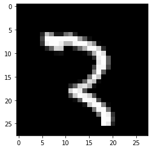

```python
import matplotlib.pyplot as plt
%matplotlib inline
plt.imshow(X_trainOrg[500],cmap='gray')
```

```python
print(y_trainOrg[500])
```

```
3
```

```python
from keras.utils import to_categorical
#one-hot encode target column
y_train = to_categorical(y_trainOrg)
y_test = to_categorical(y_testOrg)
```

```python
print(y_train[500])
```

```
[0. 0. 0. 1. 0. 0. 0. 0. 0. 0.]
```

```python
#reshape data to fit model
X_train = X_trainOrg.reshape(60000,28,28,1)
X_test = X_testOrg.reshape(10000,28,28,1)
```

```python
from keras.models import Sequential
from keras.layers import Dense, Conv2D, Flatten
#create model
model = Sequential()
#add model layers
model.add(Conv2D(64, kernel_size=3, activation='relu', input_shape=(28,28,1)))
model.add(Conv2D(32, kernel_size=3, activation='relu'))
model.add(Flatten())

model.add(Dense(10, activation='softmax')) #output
```

[output not shown]

```python
#compile model using accuracy to measure model performance
model.compile(optimizer='adam', loss='categorical_crossentropy', metrics=['accuracy'])
```

[output not shown]

```python
#train the model
model.fit(X_train, y_train, validation_data=(X_test, y_test), epochs=3)
```

[output not shown]

```
Train on 60000 samples, validate on 10000 samples
```

```
<keras.callbacks.History at 0x19f5f30dfd0>
```

```python
result=model.predict(X_test)
```

[figure not shown]

```python
plt.imshow(X_trainOrg[10],cmap='gray')
```

```python
print(result[10])
```

[output not shown]